#### Modeling

A variety of modeling techniques were tried to find the best possible accuracy, some including principal components analysis as a preprocessing step, others not. For brevity, the details of those models are not detailed here, but a summary of the obtained classification accuracy is below for reference.

**fit** - Classification tree (rpart) = Test Set Accuracy 0.4959  
**fit2** - Linear discriminant analysis (lda) = Test Set Accuracy 0.7068  
**fit3** - Classification tree with PCA pre-processing = Test Set Accuracy 0.4345  
**fit4** - Linear discriminant analysis with PCA pre-processing = Test Set Accuracy 0.5381  
**fit5** - Random forest (ntree = 1) = Test Set Accuracy 0.9366  
**fit6** - Random forest (ntree = 10) = Test Set Accuracy 0.9857  
**fit7** - Random forest (ntree = 20) = Test Set Accuracy 0.9882

*(Note that for the random forest fits, I had to limit the number of trees because I did not have enough memory on my machine to handle the default of 500, and was getting nasty memory allocation errors in R.)*

Ultimately, fit7 was selected as the best model on the basis of test set prediction accuracy; it was generated and tested as follows:

```r
fit7 <- train(classe ~., method = "rf", data = train, ntree = 20)
```

The parameters of the final model:

```r
fit7
```

```
## Random Forest
##
## 14718 samples
##    52 predictor
##     5 classes: 'A', 'B', 'C', 'D', 'E'
##
## No pre-processing
## Resampling: Bootstrapped (25 reps)
## Summary of sample sizes: 14718, 14718, 14718, 14718, 14718, 14718, ...
## Resampling results across tuning parameters:
##
##   mtry  Accuracy   Kappa
##    2    0.9824682  0.9778166
##   27    0.9867626  0.9832535
##   52    0.9763897  0.9701298
##
## Accuracy was used to select the optimal model using  the largest value.
## The final value used for the model was mtry = 27.
```

```r
fit7$finalModel
```

```
##
## Call:
##  randomForest(x = x, y = y, ntree = 20, mtry = param$mtry)
##                Type of random forest: classification
##                      Number of trees: 20
## No. of variables tried at each split: 27
##
##         OOB estimate of  error rate: 1.69%
## Confusion matrix:
##      A    B    C    D    E class.error
## A 4161   17    4    0    3 0.005734767
## B   30 2778   32    4    4 0.024578652
## C    4   31 2511   21    0 0.021815349
## D    6    7   45 2350    3 0.025300705
## E    3   11    8   15 2668 0.013678373
```

The model’s performance as applied to the test set:

```r
confusionMatrix(test$classe, predict(fit7, newdata = test))
```

```
## Confusion Matrix and Statistics
##
##           Reference
## Prediction    A    B    C    D    E
##          A 1387    3    5    0    0
##          B    4  942    2    1    0
##          C    1   11  835    8    0
##          D    0    2   12  790    0
##          E    0    2    2    5  892
##
## Overall Statistics
##
##                Accuracy : 0.9882
##                  95% CI : (0.9847, 0.991)
##     No Information Rate : 0.2838
##     P-Value [Acc > NIR] : < 2.2e-16
##
##                   Kappa : 0.985
##  Mcnemar's Test P-Value : NA
##
## Statistics by Class:
##
##                      Class: A Class: B Class: C Class: D Class: E
## Sensitivity            0.9964   0.9812   0.9755   0.9826   1.0000
## Specificity            0.9977   0.9982   0.9951   0.9966   0.9978
## Pos Pred Value         0.9943   0.9926   0.9766   0.9826   0.9900
## Neg Pred Value         0.9986   0.9954   0.9948   0.9966   1.0000
## Prevalence             0.2838   0.1958   0.1746   0.1639   0.1819
## Detection Rate         0.2828   0.1921   0.1703   0.1611   0.1819
## Detection Prevalence   0.2845   0.1935   0.1743   0.1639   0.1837
## Balanced Accuracy      0.9971   0.9897   0.9853   0.9896   0.9989
```

Accuracy per number of predictors selected for use in the model:

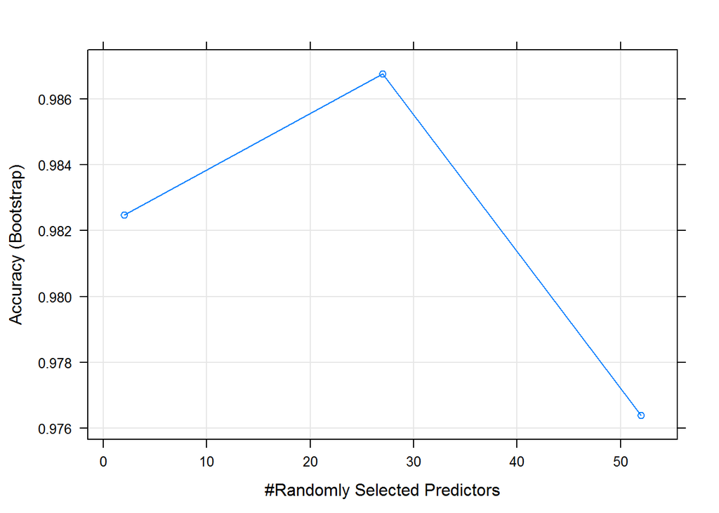

```r
plot(fit7)
```

#### Validation

With the model performing well, it was used to predict the twenty additional cases in the validation set.

```r
predict(fit7, newdata = validation)
```

```
##  [1] B A B A A E D B A A B C B A E E A B B B
## Levels: A B C D E
```